# PSL: Logistic Regression

Week 8 Example (Fall 2025)

```python
import pandas as pd
import numpy as np
import statsmodels.api as sm
import matplotlib.pyplot as plt
from sklearn.linear_model import LogisticRegression
from sklearn.preprocessing import StandardScaler
from scipy.optimize import minimize
import warnings
warnings.filterwarnings('ignore')
```

In this example we are going to work with the South Africa heart data that can be found [here](https://web.stanford.edu/~hastie/ElemStatLearn/datasets/SAheart.data).

```python
url = "https://web.stanford.edu/~hastie/ElemStatLearn/datasets/SAheart.data"
SAheart = pd.read_csv(url, index_col=0)
SAheart.head()
```

| row.names | sbp | tobacco | ldl | adiposity | famhist | typea | obesity | alcohol | age | chd |
| --- | --- | --- | --- | --- | --- | --- | --- | --- | --- | --- |
| 1 | 160 | 12.00 | 5.73 | 23.11 | Present | 49 | 25.30 | 97.20 | 52 | 1 |
| 2 | 144 | 0.01 | 4.41 | 28.61 | Absent | 55 | 28.87 | 2.06 | 63 | 1 |
| 3 | 118 | 0.08 | 3.48 | 32.28 | Present | 52 | 29.14 | 3.81 | 46 | 0 |
| 4 | 170 | 7.50 | 6.41 | 38.03 | Present | 51 | 31.99 | 24.26 | 58 | 1 |
| 5 | 134 | 13.60 | 3.50 | 27.78 | Present | 60 | 25.99 | 57.34 | 49 | 1 |

The SAheart data set is the outcome of a study of heart disease risk factors among South African men of mixed ancestry. It contains 462 observations with variables that describe lifestyle, medical history, and physiological measures—such as age, alcohol intake, tobacco use, blood pressure, cholesterol levels, and family history of heart disease.

Our goal in this example is to estimate the probability that an individual had coronary heart disease (CHD).

The data set consists of the following variables:

- `sbp` - systolic blood pressure
- `tobacco` - cumulative tobacco (kg)
- `ldl` - low density lipoprotein cholesterol
- `adiposity` - numeric measure of a person’s relative body fat.
- `famhist` - family history of heart disease (Present, Absent)
- `typea` - type-A behavior
- `obesity`
- `alcohol` - current alcohol consumption
- `age` - age at onset

```python
from statsmodels.api import Logit, add_constant

SAheart_encoded = SAheart.copy()
SAheart_encoded['famhist'] = (SAheart_encoded['famhist'] == 'Present').astype(int) # statsmodel expects numeric

X = add_constant(SAheart_encoded.drop('chd', axis=1))
y = SAheart_encoded['chd']

heart_logistic = Logit(y, X).fit()
heart_logistic.summary()
```

```
Optimization terminated successfully.
         Current function value: 0.510974
         Iterations 6
```

Logit Regression Results

| Dep. Variable: | chd | No. Observations: | 462 |
| --- | --- | --- | --- |
| Model: | Logit | Df Residuals: | 452 |
| Method: | MLE | Df Model: | 9 |
| Date: | Thu, 02 Oct 2025 | Pseudo R-squ.: | 0.2080 |
| Time: | 21:48:20 | Log-Likelihood: | -236.07 |
| converged: | True | LL-Null: | -298.05 |
| Covariance Type: | nonrobust | LLR p-value: | 2.055e-22 |

|  | coef | std err | z | P>\|z\| | [0.025 | 0.975] |
| --- | --- | --- | --- | --- | --- | --- |
| const | -6.1507 | 1.308 | -4.701 | 0.000 | -8.715 | -3.587 |
| sbp | 0.0065 | 0.006 | 1.135 | 0.256 | -0.005 | 0.018 |
| tobacco | 0.0794 | 0.027 | 2.984 | 0.003 | 0.027 | 0.132 |
| ldl | 0.1739 | 0.060 | 2.915 | 0.004 | 0.057 | 0.291 |
| adiposity | 0.0186 | 0.029 | 0.635 | 0.526 | -0.039 | 0.076 |
| famhist | 0.9254 | 0.228 | 4.061 | 0.000 | 0.479 | 1.372 |
| typea | 0.0396 | 0.012 | 3.214 | 0.001 | 0.015 | 0.064 |
| obesity | -0.0629 | 0.044 | -1.422 | 0.155 | -0.150 | 0.024 |
| alcohol | 0.0001 | 0.004 | 0.027 | 0.978 | -0.009 | 0.009 |
| age | 0.0452 | 0.012 | 3.728 | 0.000 | 0.021 | 0.069 |

We obtain the fitted values for the regression model, and we report in a table:

```python
yhat = (heart_logistic.predict(X) > 0.5).astype(int)
pd.crosstab(yhat, y, rownames=['Predicted'], colnames=['Actual'])
```

| Actual Predicted | 0 | 1 |
| --- | --- | --- |
| 0 | 256 | 77 |
| 1 | 46 | 83 |

### Goodness-of-Fit

- **Null Deviance**: The deviance a associated with a logistic regression model that includes only the intercept term (i.e., it doesn’t consider any predictor variables). In this case, the estimated probability $P(Y=1|X=x_i)$ is determined solely by the sample mean of the observed 𝑦𝑖 values, irrespective of the feature vector $x_i$.
- **Residual Deviance**: This deviance corresponds to the current logistic regression model under consideration. For example, for the logistic regression model we just fit, and the estimated probability of $P(Y=1|X=x_i)$ obtained using the model fitted values.

We can also compute them here

```python
p_hat = heart_logistic.predict(X)
residual_deviance = -2 * (np.sum(np.log(p_hat[y == 1])) + np.sum(np.log(1 - p_hat[y == 0])))
print(f"Residual Deviance: {residual_deviance:.4f}")
```

```
Residual Deviance: 472.1400
```

```python
p0_hat = np.full(len(y), y.mean())
null_deviance = -2 * (np.sum(np.log(p0_hat[y == 1])) + np.sum(np.log(1 - p0_hat[y == 0])))
print(f"Null Deviance: {null_deviance:.4f}")
```

```
Null Deviance: 596.1084
```

### Numerical Optimization

Coding up the function from scratch without statsmodel

```python
def logistic_loglik(b, x, y):
    xb = x @ b # matrix multiplication
    return np.sum(y * xb) - np.sum(np.log(1 + np.exp(xb)))

def logistic_gradient(b, x, y):
    expxb = np.exp(x @ b)
    return x.T @ (y - expxb / (1 + expxb))

x_mat = X.values
y_vec = y.values
b_init = np.zeros(x_mat.shape[1])

result = minimize(lambda b: -logistic_loglik(b, x_mat, y_vec),
                  b_init,
                  method='BFGS',
                  jac=lambda b: -logistic_gradient(b, x_mat, y_vec))

print("Coefficients:")
for name, coef in zip(X.columns, result.x):
    print(f"{name}: {coef:.6f}")
```

```
Coefficients:
const: -6.150721
sbp: 0.006504
tobacco: 0.079376
ldl: 0.173924
adiposity: 0.018587
famhist: 0.925370
typea: 0.039595
obesity: -0.062910
alcohol: 0.000122
age: 0.045225
```

Our result here matches the results from statsmodels. If a general solver function is not readily available, we can always use Newton-Raphson. For that, you will need to write a function to calculate the Hessian matrix and then proceed to optimization.

### Variable Selection

Variable selection might also be necessary when working in a logistic regression framework. So, we will explore which methods/criteria that we used in regression can seamlessly transfer to logistic regression.

#### AIC/BIC {-}

We can employ criteria such as AIC and BIC because the logistic regression model has a likelihood. However, unlike linear regression, we are not able to employ the leaps-and-bounds algorithm to explore all possible sub-models since the likelihood in logistic regression differs from residual sum of squares. Instead, we rely on a greedy algorithm, such as stepwise, backward, or forward.

As an example

```python
def stepwise_logistic(X, y):
    included = [] # initialize list of variables

    while True:
        changed = False # if neither forward nor backstep produce  desired change, stop

        # Forward step
        excluded = list(set(X.columns) - set(included)) # list of variables to try
        new_aic = pd.Series(index=excluded, dtype='float64')
        for new_column in excluded:
            model = sm.Logit(y, sm.add_constant(X[included + [new_column]])).fit(disp=0)
            new_aic[new_column] = model.aic

        # Current model's AIC
        current_model = sm.Logit(y, sm.add_constant(X[included])).fit(disp=0)
        current_aic = current_model.aic

        # Decide if adding a variable is best
        best_new_aic = new_aic.min()
        if best_new_aic < current_aic:
            best_feature = new_aic.idxmin()
            included.append(best_feature)
            changed = True


        # Backward step
        # Re-evaluate current model after potential addition
        current_model = sm.Logit(y, sm.add_constant(X[included])).fit(disp=0)
        current_aic = current_model.aic

        aic_with_drop = pd.Series(index=included, dtype='float64')
        for col_to_drop in included:
            model = sm.Logit(y, sm.add_constant(X[included].drop(col_to_drop, axis=1))).fit(disp=0)
            aic_with_drop[col_to_drop] = model.aic

        best_drop_aic = aic_with_drop.min()
        if best_drop_aic < current_aic:
            worst_feature = aic_with_drop.idxmin()
            included.remove(worst_feature)
            changed = True

        if not changed: # meaning no forward or
            break

    final_model = sm.Logit(y, sm.add_constant(X[included])).fit(disp=0)
    return final_model
```

```python
final_model = stepwise_logistic(X,y)
final_model.summary()
```

Logit Regression Results

| Dep. Variable: | chd | No. Observations: | 462 |
| --- | --- | --- | --- |
| Model: | Logit | Df Residuals: | 456 |
| Method: | MLE | Df Model: | 5 |
| Date: | Thu, 02 Oct 2025 | Pseudo R-squ.: | 0.2020 |
| Time: | 21:49:04 | Log-Likelihood: | -237.84 |
| converged: | True | LL-Null: | -298.05 |
| Covariance Type: | nonrobust | LLR p-value: | 2.554e-24 |

|  | coef | std err | z | P>\|z\| | [0.025 | 0.975] |
| --- | --- | --- | --- | --- | --- | --- |
| const | -6.4464 | 0.921 | -7.000 | 0.000 | -8.251 | -4.642 |
| age | 0.0505 | 0.010 | 4.944 | 0.000 | 0.030 | 0.070 |
| famhist | 0.9082 | 0.226 | 4.023 | 0.000 | 0.466 | 1.351 |
| tobacco | 0.0804 | 0.026 | 3.106 | 0.002 | 0.030 | 0.131 |
| typea | 0.0371 | 0.012 | 3.051 | 0.002 | 0.013 | 0.061 |
| ldl | 0.1620 | 0.055 | 2.947 | 0.003 | 0.054 | 0.270 |

#### Penalized Logistic Regression {-}

In Logistic regression, we can also use penalization techniques to regularize our model

```python
from sklearn.linear_model import LogisticRegressionCV

X_features = SAheart_encoded.drop('chd', axis=1)
lasso_fit = LogisticRegressionCV(cv=10, penalty='l1', solver='saga', max_iter=10000)
lasso_fit.fit(X_features, y)

print("Coefficients:")
for name, coef in zip(X_features.columns, lasso_fit.coef_[0]):
    print(f"{name}: {coef:.6f}")
```

```
Coefficients:
sbp: -0.004683
tobacco: 0.083028
ldl: 0.163339
adiposity: 0.057420
famhist: 0.795534
typea: 0.015056
obesity: -0.155607
alcohol: 0.000030
age: 0.030499
```

## Illustration of MLE Divergence

Consider a very simple case in which

$$ y = \begin{cases} 1, & \text{if } x_1 - 2 x_2 > 0 \\ 0, & \text{otherwise} \end{cases} $$

Simulate such data:

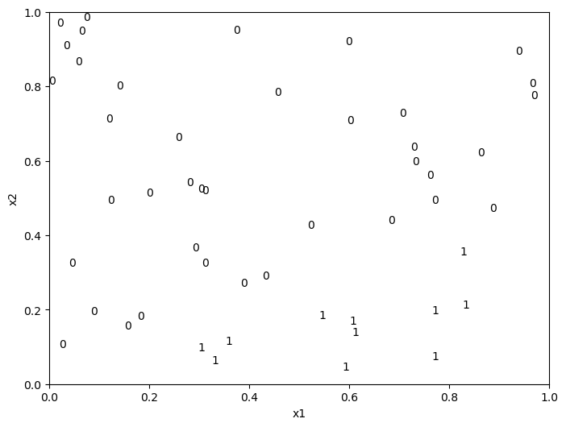

```python
np.random.seed(42)
x = np.random.uniform(0, 1, (50, 2))
y_sep = (x[:, 0] - 2 * x[:, 1] > 0).astype(int)

plt.figure(figsize=(8, 6))
for i in range(len(x)):
    plt.text(x[i, 0], x[i, 1], str(y_sep[i]), ha='center', va='center')
plt.xlabel('x1')
plt.ylabel('x2')
plt.show()
```

```python
X_sep = add_constant(x)
logistic_sep = Logit(y_sep, X_sep).fit()
np.round(logistic_sep.predict(X_sep), 0)
```

```
array([0., 0., 0., 0., 0., 0., 1., 0., 0., 0., 1., 0., 0., 0., 1., 1., 0.,
       0., 1., 0., 0., 0., 0., 0., 1., 0., 0., 0., 0., 0., 0., 1., 0., 0.,
       0., 1., 0., 0., 1., 1., 0., 1., 0., 0., 0., 0., 0., 0., 0., 0.])
```